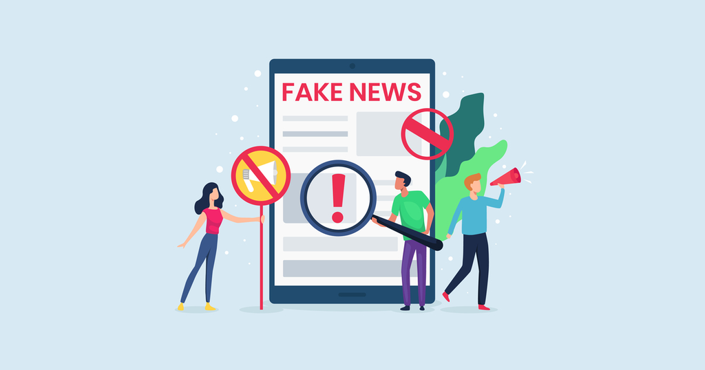

# Introduction

Fake news is a broad term and in this project our focus will be on covid-19 tweets and online articles whether the infomation presented to the reader is fake or real. In this notebook, we will leverage the prepared datasets which can be found in the data preparation notebook in this project attachments to create models that will help us predict whether the tweet you would like to read or the article you are interested in reading tend to be reliable or fake.

## Problem understanding

News can be in many different forms. For example, Newspapers, Magazines, TV and radio, Internet, News agencies and Alternative media. Now, there are some businesses that try to promote their products or to advertise a product and some publish fake, attractive or charming news as 'clickbait' and we tend to be curious when it comes to unusual things and so we read / check the content. For instance, in 1835 newspaper company claimed that they have found out creates live in moon (humans with wings) [here is link for full article](https://www.newyorker.com/books/page-turner/moon-shot-race-a-hoax-and-the-birth-of-fake-news). That as a consequence allowed the company to be more popular which allowed them to promote and advertise more. Now this is one of the reasons why would certain group of people / a person publish fake news or misleading information. However, the influnce on the reader is usually harmful. For example, it could be that fake news regards healthy food suggest or recommend some types of food for people who suffer from kind of illness and if reader followed the suggestions that could be in fact harmful for them since news were fake in the first place. There are more scenarios obviously but this is where the problem lies. Fake news in general are published for the sake of obtaining profit most of the time and readers might believe misleading information which could influence their decisions.

In this research though, the focus will be on the news of covid-19 topic (tweets) and various topics of fake, legit articles published on the internet.

## Expectations of this notebook

After reading this notebook you should have:

- Gained basic understanding of the prepared data
- Seen data visualization about the length of the text and count of important words against the reliability
- Understood how the preparation procedure has been done
- Seen different model performances

## Table of content:

- Introduction
- Loading libraries and dataset
- Data basic understanding
- Data basic level information
- Visualizations
- Preparation
- Modelling
- Conclusion

# Loading libraries and dataset

```python
import pandas as pd
import numpy as np
import matplotlib.pyplot as plt
import seaborn as sns
%matplotlib inline

#Preparation
from sklearn.feature_extraction.text import TfidfVectorizer
from sklearn.model_selection import train_test_split

#Hyperparameters tuning
from sklearn.model_selection import GridSearchCV
from sklearn.pipeline import Pipeline

#Models
from sklearn.naive_bayes import MultinomialNB
from sklearn.linear_model import SGDClassifier
from sklearn.ensemble import RandomForestClassifier
from sklearn.tree import DecisionTreeClassifier

#Evaluation
from sklearn.metrics import classification_report,confusion_matrix
from sklearn.model_selection import cross_val_score
```

```python
covid19_tweets = pd.read_csv('covid_tweets_prepared.csv',index_col=0)
```

```python
online_articles = pd.read_csv('online_articles_prepared.csv',index_col=0)
```

## Explanation of the loaded libraries

- pandas is a fast, powerful, flexible and easy to use open source data analysis and manipulation tool, built on top of the Python programming language.
- NumPy is the fundamental package for scientific computing in Python. It is a Python library that provides a multidimensional array object, various derived objects (such as masked arrays and matrices), and an assortment of routines for fast operations on arrays, including mathematical, logical, shape manipulation, sorting, selecting, I/O, discrete Fourier transforms, basic linear algebra, basic statistical operations, random simulation and much more.
- Matplotlib is a plotting library for the Python programming language and its numerical mathematics extension NumPy.
- Seaborn is a data visualization library built on top of matplotlib and closely integrated with pandas data structures in Python.
- TfidfVectorizer - It is a technique used for natural language processing, that transforms text to feature vectors that can be used as input to the estimator.
- train_test_split is a function in Sklearn model selection for splitting data arrays into two subsets: for training data and for testing data.
- GridSearchCV is a library function that is a member of sklearn's model_selection package. It helps to loop through predefined hyperparameters and fit your estimator (model) on your training set. So, in the end, you can select the best parameters from the listed hyperparameters.
- The purpose of the pipeline is to assemble several steps that can be cross-validated together while setting different parameters.
- The multinomial Naive Bayes classifier is suitable for classification with discrete features (e.g., word counts for text classification)
- SGDClassifier is a linear classifier (by default in sklearn it is a linear SVM) that uses SGD for training (that is, looking for the minima of the loss using SGD). According to the documentation: SGDClassifier is a Linear classifiers (SVM, logistic regression, a.o.) with SGD training.
- Random Forest is a robust machine learning algorithm that can be used for a variety of tasks including regression and classification.
- DecisionTreeClassifier is a class capable of performing multi-class classification on a dataset
- Classification report Text summary of the precision, recall, F1 score for each class
- Confusion matrix, also known as an error matrix, is a specific table layout that allows visualization of the performance of an algorithm, typically a supervised learning one
- The cross_val_score() function will be used to perform the evaluation, taking the dataset and cross-validation configuration and returning a list of scores calculated for each fold

# Data basic understanding

In this section of the modelling phase I shall descripe the prepared data so that it is not nessacary to read the all notebooks but it is the reader's choice to. In addition to that, I will demonstrate basic level information of the datasets such as the shape, columns, first a few rows and if the datasets are balanced or not.

## Data description

**covid19_tweets** is a dataset that contains tweets taken from twitter reagrding covid 19 period in 2021. The dataset owner has classified the tweets in label coumn as fake or real. The data has been explored and the sources of the data are available in the proposal and the EDA part of data collection. The data has also been prepared in the preparation notebook. In general the data currently contains text that has been processed so all text lowered, expanded contractions (example, it's --> it is), emojis, digits, hyperlinks, hashtags and stop words has been removed. Lastly, all words have been reversed back to its orginal form using lemmatization technique (example, went --> go, gone --> go).

**online_articles** is a dataset that contains fake articles that have been taken from kaggle and merged with real articles taken from [allsides](https://www.allsides.com/about). The dataset owner has merged both dataset and published the finalized dataset which is used in this project [dataset article](https://opendatascience.com/how-to-build-a-fake-news-classification-model/),[github link](https://github.com/ricknta/fake-news). The data has been explored and the sources of the data are available in the proposal and the EDA part of data collection. The data has also been prepared in the preparation notebook. In general the data currently contains text that has been processed so all text lowered, expanded contractions (example, it's --> it is), emojis, digits and stop words has been removed. Lastly, all words have been reversed back to its orginal form using lemmatization technique (example, went --> go, gone --> go).

# Data basic level information

## Covid 19 dataset

```python
covid19_tweets.shape
```

```
(6228, 2)
```

```python
covid19_tweets.columns
```

```
Index(['prepared', 'label'], dtype='object')
```

```python
covid19_tweets.head()
```

|  | prepared | label |
| --- | --- | --- |
| 0 | cdc currently report death general discrepan... | real |
| 1 | state report death small rise tuesday southe... | real |
| 2 | politically correct woman use pandemic excuse ... | fake |
| 3 | test laboratory india th august test ... | real |
| 4 | populous state generate large case count look ... | real |

```python
covid19_tweets.tail()
```

|  | prepared | label |
| --- | --- | --- |
| 6415 | tiger test positive covid stay away pet bird | fake |
| 6416 | autopsy prove covid blood clot pneumonia ought... | fake |
| 6417 | post claim covid vaccine develop cause widespr... | fake |
| 6418 | aamir khan donate cr pm relief care fund | fake |
| 6419 | day case covid acquire locally unknown sourc... | real |

```python
covid19_tweets.describe()
```

|  | prepared | label |
| --- | --- | --- |
| count | 6228 | 6228 |
| unique | 6228 | 2 |
| top | psychiatrist fear people covidsorting similar ... | real |
| freq | 1 | 3219 |

```python
covid19_tweets.label.value_counts()
```

```
real    3219
fake    3009
Name: label, dtype: int64
```

```python
covid19_tweets.dtypes
```

```
prepared    object
label       object
dtype: object
```

## Online articles dataset

```python
online_articles.shape
```

```
(5991, 2)
```

```python
online_articles.columns
```

```
Index(['prepared', 'label'], dtype='object')
```

```python
online_articles.head()
```

|  | prepared | label |
| --- | --- | --- |
| 0 | daniel greenfield shillman journalism fellow f... | fake |
| 1 | google pinter digg linkedin reddit stumbleupon... | fake |
| 2 | secretary state john f kerry say monday stop p... | real |
| 3 | — kaydee king kaydeeke november lesson toni... | fake |
| 4 | primary day new york frontrunner hillary clint... | real |

```python
online_articles.tail()
```

|  | prepared | label |
| --- | --- | --- |
| 6330 | state department tell republican national comm... | real |
| 6331 | ' p ' pbs stand ' plutocratic ' ' pentagon ' p... | fake |
| 6332 | antitrump protester tool oligarchy reform p... | fake |
| 6333 | addis ababa ethiopia — president obama convene... | real |
| 6334 | jeb bush suddenly attack trump matter \n\n jeb... | real |

```python
online_articles.describe()
```

|  | prepared | label |
| --- | --- | --- |
| count | 5991 | 5991 |
| unique | 5981 | 2 |
| top | notify followup comment email notify new post ... | fake |
| freq | 7 | 3039 |

```python
online_articles.label.value_counts()
```

```
fake    3039
real    2952
Name: label, dtype: int64
```

```python
online_articles.dtypes
```

```
prepared    object
label       object
dtype: object
```

# Visualizations

In this section of modelling phase notebook I show some data visualizations about the balance for each dataset, I will also be calculating the amount of characters (length) per article/tweet and use heatmap to display the relationship. Next, I will refer back to important words for each dataset (which was shown previously in the data preparation notebook) then count the amount of times those words are counted per article/tweet and use heatmap to show relationship between those words and the reliability. Lastly, The results will be concluded in a short way to wrap up this sub-section.

## Pre-visualizing

As mentioned in the above description of this sub-section, calculating the length of the tweet/articles is needed to display the relationship in a heatmap. Therefore, in this part I will calculate the length.

```python
covid19_tweets["Length"] = covid19_tweets["prepared"].apply(len)
```

```python
online_articles["Length"] = online_articles["prepared"].apply(len)
```

```python
covid19_tweets[['label','Length']].groupby('label').describe()
```

| label | Length count | Length mean | Length std | Length min | Length 25% | Length 50% | Length 75% | Length max |
| --- | --- | --- | --- | --- | --- | --- | --- | --- |
| fake | 3009.0 | 83.938518 | 133.109924 | 4.0 | 48.0 | 67.0 | 101.0 | 5999.0 |
| real | 3219.0 | 110.408823 | 41.303347 | 2.0 | 77.0 | 111.0 | 143.0 | 239.0 |

```python
online_articles[['label','Length']].groupby('label').describe()
```

| label | Length count | Length mean | Length std | Length min | Length 25% | Length 50% | Length 75% | Length max |
| --- | --- | --- | --- | --- | --- | --- | --- | --- |
| fake | 3039.0 | 2596.634090 | 3405.755523 | 2.0 | 837.00 | 1627.0 | 3219.0 | 61225.0 |
| real | 2952.0 | 3479.741192 | 2647.644092 | 22.0 | 1924.25 | 3015.0 | 4326.5 | 26541.0 |

## One hot encoding

In this part I will use the one hot encoding technique to represent the reliability of the article/tweet as columns so that we can visualize relationship using heatmap later on. [get_dummies](https://pandas.pydata.org/docs/reference/api/pandas.get_dummies.html) This method will be used to complete this part.

```python
covid19_label = pd.get_dummies(covid19_tweets.label)
covid19_label.head(2)
```

|  | fake | real |
| --- | --- | --- |
| 0 | 0 | 1 |
| 1 | 0 | 1 |

```python
articles_label = pd.get_dummies(online_articles.label)
articles_label.head(2)
```

|  | fake | real |
| --- | --- | --- |
| 0 | 1 | 0 |
| 1 | 1 | 0 |

```python
#create edited version of the datasets after merging with one hot coded columns
covid19_tweets_edited = pd.concat([covid19_tweets,covid19_label],axis=1)
covid19_tweets_edited.drop('label',axis=1,inplace=True)

online_articles_edited = pd.concat([online_articles,articles_label],axis=1)
online_articles_edited.drop('label',axis=1,inplace=True)
```

```python
covid19_tweets_edited.head(3)
```

|  | prepared | Length | fake | real |
| --- | --- | --- | --- | --- |
| 0 | cdc currently report death general discrepan... | 134 | 0 | 1 |
| 1 | state report death small rise tuesday southe... | 69 | 0 | 1 |
| 2 | politically correct woman use pandemic excuse ... | 66 | 1 | 0 |

```python
online_articles_edited.head(3)
```

|  | prepared | Length | fake | real |
| --- | --- | --- | --- | --- |
| 0 | daniel greenfield shillman journalism fellow f... | 4344 | 1 | 0 |
| 1 | google pinter digg linkedin reddit stumbleupon... | 1561 | 1 | 0 |
| 2 | secretary state john f kerry say monday stop p... | 1639 | 0 | 1 |

## Visualizing the data balance

We have derived that both datasets are balanced in the data basic level information section. However, the point of visualizing data is to show the numbers in data visualization so that humans can read it and notice difference quickly in comparison to just reading numbers. Therefore, in this part I will plot the amount of reliable and unreliable tweets/articles.

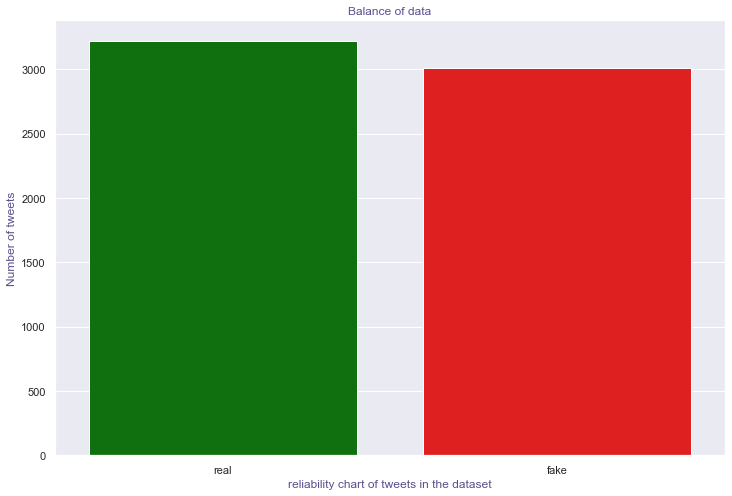

```python
#Palette
cols= ["Green", "Red"]
#first of all let us evaluate the target and find out if our data is imbalanced or not
plt.figure(figsize=(12,8))
fg = sns.countplot(x= covid19_tweets["label"], palette= cols)
fg.set_title("Balance of data", color="#58508d")
fg.set_xlabel("reliability chart of tweets in the dataset", color="#58508d")
fg.set_ylabel("Number of tweets", color="#58508d")
```

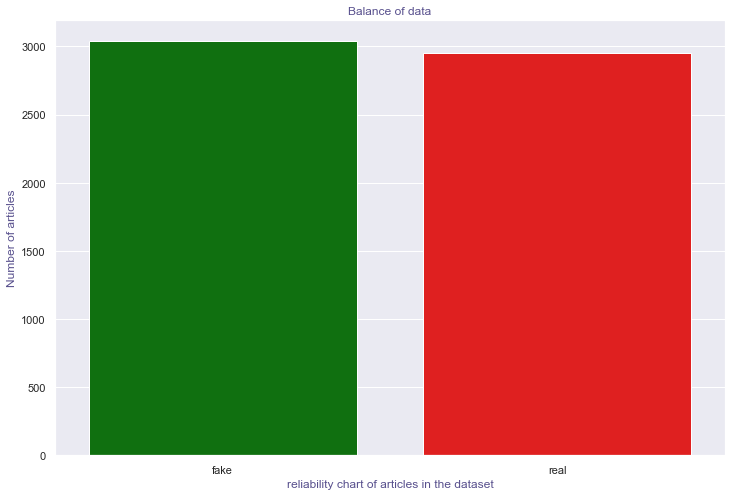

```python
#Palette
cols= ["Green", "Red"]
#first of all let us evaluate the target and find out if our data is imbalanced or not
plt.figure(figsize=(12,8))
fg = sns.countplot(x= online_articles["label"], palette= cols)
fg.set_title("Balance of data", color="#58508d")
fg.set_xlabel("reliability chart of articles in the dataset", color="#58508d")
fg.set_ylabel("Number of articles", color="#58508d")
```

## Relationship between prepared text length and the reliability

In this section, we will leverage the length column we calculated in the previous section to see the correlation between it and the reliability.

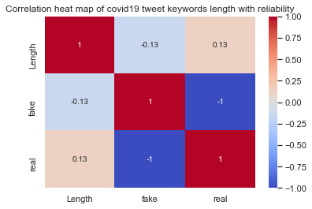

```python
ax = plt.axes()
sns.heatmap(covid19_tweets_edited.corr(),annot=True,cmap='coolwarm')
ax.set_title('Correlation heat map of covid19 tweet keywords length with reliability')
```

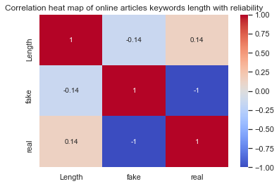

```python
ax = plt.axes()
sns.heatmap(online_articles_edited.corr(),annot=True,cmap='coolwarm')
ax.set_title('Correlation heat map of online articles keywords length with reliability')
```

## Findings

We can notice that fake or unreliable tend to have less amount of keywords. This support one of the hypotheses I explored in the EDA notebook where I stated that I the more information displayed indicate more clarification to the matter which result in a reliable content/news. Now 13% - 14% correlation is not high percentage so this can be true to some extent and not always true.

## Relationship between the most of occurences of important words against the reliability

In this part, the word cloud of important words for covid 19 tweets and online articles will be displayed. Then we will take top 10 words that are important and count how many times they occured per article/tweet. Lastly, we will display the relationship between those words using heatmap and wrap this part with the findings.

First we will check the word cloud of real covid-19 news then fake ones.

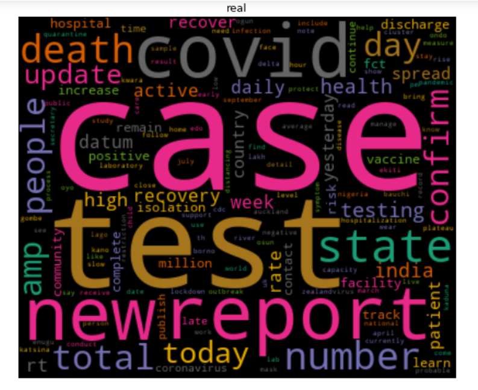

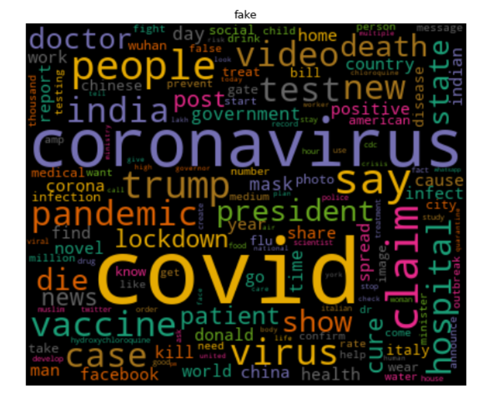

- Chosen top covid19 important words for real tweets (Case,Test,Report,Confirm,Update,Covid)
- Chosen top covid19 important words for fake tweets (Covid,vaccine,cure,claim,say)

```python
top10_covid19_words = ['case','test','report','confirm','update','covid','vaccine','cure','claim','say']
```

Now I will create a feature for each word to represent the amount of occurences in the edited version of covid dataset. This should be done so that I can see correlations between those words and the reliability of the tweet if those words mentioned.

```python
for word in top10_covid19_words :
    covid19_tweets_edited[word] = 0
covid19_tweets_edited.columns
```

```
Index(['prepared', 'Length', 'fake', 'real', 'case', 'test', 'report',
       'confirm', 'update', 'covid', 'vaccine', 'cure', 'claim', 'say'],
      dtype='object')
```

Second we will check the word cloud of real articles then fake ones.

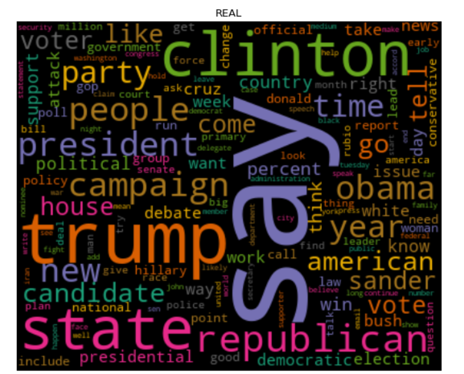

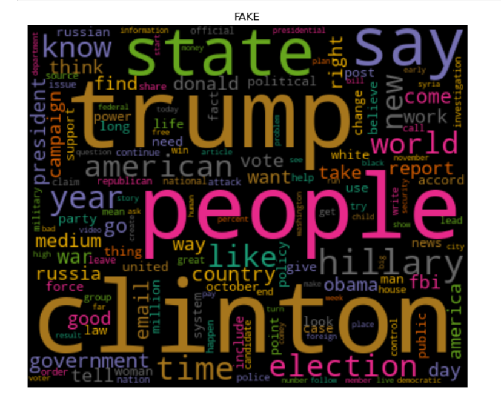

- Chosen top covid19 important words for real tweets (say,clination,president,campaign,obama,trump)
- Chosen top covid19 important words for fake tweets (clination,people,state,election,hillary)

```python
top10_online_articles_words = ['say','clinton','president','campaign','obama','trump','people','state','election','hillary']
```

Now I will create a feature for each word to represent the amount of occurences in the edited version of online articles dataset. This should be done so that I can see correlations between those words and the reliability of the article if those words mentioned.

```python
for word in top10_online_articles_words :
    online_articles_edited[word] = 0
online_articles_edited.columns
```

```
Index(['prepared', 'Length', 'fake', 'real', 'say', 'clinton', 'president',
       'campaign', 'obama', 'trump', 'people', 'state', 'election', 'hillary'],
      dtype='object')
```

Now add count amount to each word in both datasets. We will start doing it first for covid 19 edited version first then the online article one.

```python
for word in top10_covid19_words :
    covid19_tweets_edited[word] = covid19_tweets_edited['prepared'].apply(lambda t: t.split().count(word))
```

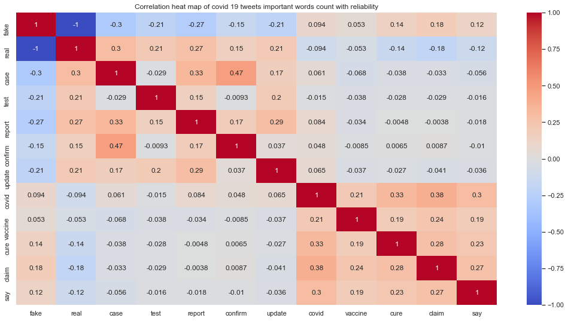

```python
sns.set(rc={'figure.figsize':(18,9)})
ax = plt.axes()
sns.heatmap(covid19_tweets_edited.drop('Length',axis=1).corr(),annot=True,cmap='coolwarm')
ax.set_title('Correlation heat map of covid 19 tweets important words count with reliability')
```

```python
for word in top10_online_articles_words :
    online_articles_edited[word] = online_articles_edited['prepared'].apply(lambda t: t.split().count(word))
```

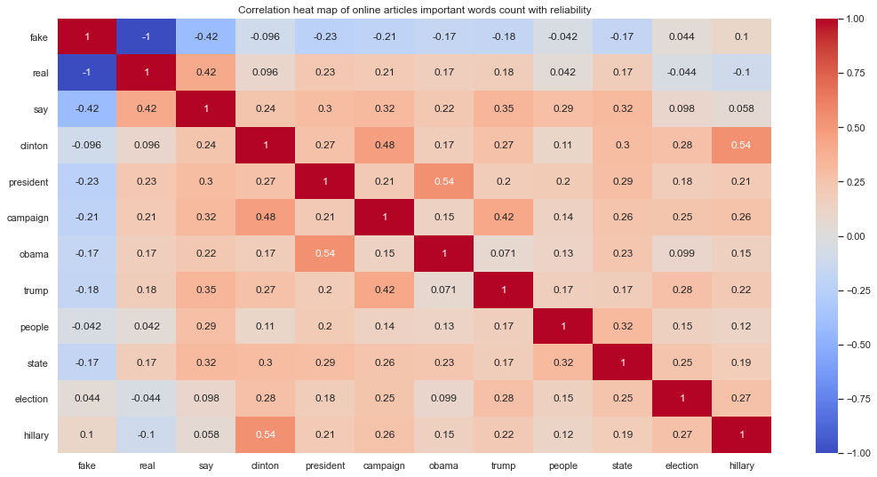

```python
sns.set(rc={'figure.figsize':(18,9)})
ax = plt.axes()
sns.heatmap(online_articles_edited.drop('Length',axis=1).corr(),annot=True,cmap='coolwarm')
ax.set_title('Correlation heat map of online articles important words count with reliability')
```

# Preparation

- In this section of the modelling phase, both datasets will be splitted into training and testing sets so that later on we train our models with training data and evaluate them with testing data. Both Covid19 tweets and online articles shall be prepared using techniques such as Feature extraction since we are working with text.
- Since this is a natural language processing project, we will use “Term Frequency — Inverse Document Frequency”. This is a technique to quantify words in a set of documents. We generally compute a score for each word to signify its importance in the document and corpus.

## Splitting the data

```python
X_covid = covid19_tweets['prepared']  # this is the prepared, cleaned text from previous covid19 eda and data preparation notebook
y_covid = covid19_tweets['label']

X_covid_train, X_covid_test, y_covid_train, y_covid_test = train_test_split(X_covid, y_covid, test_size=0.33, random_state=42)
```

```python
X_article = online_articles['prepared']  # this is the prepared, cleaned text from previous online article eda and data preparation notebook
y_article = online_articles['label']

X_article_train, X_article_test, y_article_train, y_article_test = train_test_split(X_article, y_article, test_size=0.33, random_state=42)
```

## Feature text extraction

Machine Learning algorithms learn from a pre-defined set of features from the training data to produce output for the test data. But the main problem in working with language processing is that machine learning algorithms cannot work on the raw text directly. So, we need some feature extraction techniques to convert text into a matrix(or vector) of features.

Essentially what we are doing here is that, we go through each article/tweet and create vocabulary for each dataset that contain each word and its relevance to the overall corpus of the whole given text. We will be using [TfIDF](https://scikit-learn.org/stable/modules/generated/sklearn.feature_extraction.text.TfidfVectorizer.html) to implement this part.

```python
vect_covid19 = TfidfVectorizer()
```

```python
vect_article = TfidfVectorizer()
```

```python
X_covid_train_tfidf = vect_covid19.fit_transform(X_covid_train)
```

```python
X_covid_train_tfidf.shape
```

```
(4172, 7262)
```

```python
X_article_train_tfidf = vect_article.fit_transform(X_article_train)
```

```python
X_article_train_tfidf.shape
```

```
(4013, 53886)
```

Notice that the amount of rows for both vocabularies is 4k. Our data has been split 66% into training and 33% into testing. Our data sets have roughly 6k data points and 6000 * 0.66 is about 3960 rows which is why we see 4k as our number of rows.

# Modelling

In this section of the modeling phase, several models shall be instianited and trained on the training data of covid 19 tweets and online articles. GridSearchCV would be used to tune in parameters and find out which parameters would work better.

We will be using 4 different models:

Recommended for text data:

- [MultinomialNB](https://scikit-learn.org/stable/modules/generated/sklearn.naive_bayes.MultinomialNB.html)
- [SGDClassifier](https://scikit-learn.org/stable/modules/generated/sklearn.linear_model.SGDClassifier.html)

General classification model that proved to be quite accurate:

- [RandomForestClassifier](https://scikit-learn.org/stable/modules/generated/sklearn.ensemble.RandomForestClassifier.html)
- [DecisionTreeClassifier](https://scikit-learn.org/stable/modules/tree.html)

```python
import warnings
warnings.filterwarnings('ignore')
```

## covid-19 tweets models

In this section, 4 model are going to be instaniated as mentioned in the sub-section decription. We will be using GridSearchCV to tune in hyperparameters and pipeline to repeat process for every model and evaluate the results using confusion matrix report, classification report and cross validation. Each model performance will be taken into account and a reliability chart will be created where each model performance is displayed to helping decision on which model will be selected as final chosen model for covid 19 dataset.

### MultinomialNB

Hyperparameters tuning

```python
#setting up possible tonable parameters so that gridsearchcv can search for optimal parameter value
param_grid = { 'alpha':[0,1],
                 'fit_prior':[True,False]}
```

```python
#creating the grid object
grid = GridSearchCV(MultinomialNB(),param_grid,refit=True,verbose=3)
#train the grid on the training set
grid.fit(X_covid_train_tfidf,y_covid_train)
```

[output not shown]

```
GridSearchCV(estimator=MultinomialNB(),
             param_grid={'alpha': [0, 1], 'fit_prior': [True, False]},
             verbose=3)
```

```python
grid.best_estimator_
```

```
MultinomialNB(alpha=1, fit_prior=False)
```

Building pipeline

```python
text_clf = Pipeline([('tfidf', TfidfVectorizer()),
                     ('Creating the model',  grid.best_estimator_),
])

# Feed the training data through the pipeline
text_clf.fit(X_covid_train, y_covid_train)
```

```
Pipeline(steps=[('tfidf', TfidfVectorizer()),
                ('Creating the model',
                 MultinomialNB(alpha=1, fit_prior=False))])
```

```python
# Form a prediction set
predictions = text_clf.predict(X_covid_test)
```

Confusion matrix and classification report

```python
print(confusion_matrix(y_covid_test,predictions))
print("\n")
print(classification_report(y_covid_test,predictions))
```

```
[[ 844  145]
 [  67 1000]]


              precision    recall  f1-score   support

        fake       0.93      0.85      0.89       989
        real       0.87      0.94      0.90      1067

    accuracy                           0.90      2056
   macro avg       0.90      0.90      0.90      2056
weighted avg       0.90      0.90      0.90      2056
```

Cross validation

```python
cross_val_scores = cross_val_score(text_clf, X_covid,y_covid,cv=5)
print(cross_val_scores)
```

```
[0.89085072 0.894061   0.89967897 0.91084337 0.89317269]
```

```python
#cross validation average
total = 0
for score in cross_val_scores:
    total = total + score
average_cross_val = total / len(cross_val_scores)
model1 = average_cross_val
print('MultinomialNB model of covid19 tweets average cross validation score is' + str(model1))
```

```
MultinomialNB model of covid19 tweets average cross validation score is0.8977213508931392
```

### SGDClassifier

Hyperparameters tuning

```python
#setting up possible tonable parameters so that gridsearchcv can search for optimal parameter value
param_grid = { 'penalty':['l2', 'l1', 'elasticnet'],
                 'max_iter':[1000,700,500]}
```

```python
#creating the grid object
grid = GridSearchCV(SGDClassifier(),param_grid,refit=True,verbose=3)
#train the grid on the training set
grid.fit(X_covid_train_tfidf,y_covid_train)
```

[output not shown]

```
GridSearchCV(estimator=SGDClassifier(),
             param_grid={'max_iter': [1000, 700, 500],
                         'penalty': ['l2', 'l1', 'elasticnet']},
             verbose=3)
```

```python
grid.best_estimator_
```

```
SGDClassifier(max_iter=500, penalty='elasticnet')
```

```python
text_clf = Pipeline([('tfidf', TfidfVectorizer()),
                     ('Creating the model',  grid.best_estimator_),
])

# Feed the training data through the pipeline
text_clf.fit(X_covid_train, y_covid_train)
```

```
Pipeline(steps=[('tfidf', TfidfVectorizer()),
                ('Creating the model',
                 SGDClassifier(max_iter=500, penalty='elasticnet'))])
```

```python
# Form a prediction set
predictions = text_clf.predict(X_covid_test)
```

```python
print(confusion_matrix(y_covid_test,predictions))
print("\n")
print(classification_report(y_covid_test,predictions))
```

```
[[896  93]
 [ 90 977]]


              precision    recall  f1-score   support

        fake       0.91      0.91      0.91       989
        real       0.91      0.92      0.91      1067

    accuracy                           0.91      2056
   macro avg       0.91      0.91      0.91      2056
weighted avg       0.91      0.91      0.91      2056
```

```python
cross_val_scores = cross_val_score(text_clf, X_covid,y_covid,cv=5)
print(cross_val_scores)
```

```
[0.90609952 0.91332263 0.90690209 0.92128514 0.90120482]
```

```python
#cross validation average
total = 0
for score in cross_val_scores:
    total = total + score
average_cross_val = total / len(cross_val_scores)
model2 = average_cross_val
print('SGDClassifier model of covid19 tweets average cross validation score is ' + str(model2))
```

```
SGDClassifier model of covid19 tweets average cross validation score is 0.90976283947991
```

### RandomForestClassifier

Hyperparameters tuning

```python
#setting up possible tonable parameters so that gridsearchcv can search for optimal parameter value
param_grid = { 'n_estimators':[50,100,200],
                 'max_depth':[20,50,100]}
```

```python
#creating the grid object
grid = GridSearchCV(RandomForestClassifier(),param_grid,refit=True,verbose=3)
#train the grid on the training set
grid.fit(X_covid_train_tfidf,y_covid_train)
```

[output not shown]

```
GridSearchCV(estimator=RandomForestClassifier(),
             param_grid={'max_depth': [20, 50, 100],
                         'n_estimators': [50, 100, 200]},
             verbose=3)
```

```python
grid.best_estimator_
```

```
RandomForestClassifier(max_depth=100, n_estimators=200)
```

```python
text_clf = Pipeline([('tfidf', TfidfVectorizer()),
                     ('Creating the model',  grid.best_estimator_),
])

# Feed the training data through the pipeline
text_clf.fit(X_covid_train, y_covid_train)
```

```
Pipeline(steps=[('tfidf', TfidfVectorizer()),
                ('Creating the model',
                 RandomForestClassifier(max_depth=100, n_estimators=200))])
```

```python
# Form a prediction set
predictions = text_clf.predict(X_covid_test)
```

```python
print(confusion_matrix(y_covid_test,predictions))
print("\n")
print(classification_report(y_covid_test,predictions))
```

```
[[911  78]
 [150 917]]


              precision    recall  f1-score   support

        fake       0.86      0.92      0.89       989
        real       0.92      0.86      0.89      1067

    accuracy                           0.89      2056
   macro avg       0.89      0.89      0.89      2056
weighted avg       0.89      0.89      0.89      2056
```

```python
cross_val_scores = cross_val_score(text_clf, X_covid,y_covid,cv=5)
print(cross_val_scores)
```

```
[0.88844302 0.89004815 0.89967897 0.9124498  0.89076305]
```

```python
#cross validation average
total = 0
for score in cross_val_scores:
    total = total + score
average_cross_val = total / len(cross_val_scores)
model3 = average_cross_val
print('Random forest model of covid19 tweets average cross validation score is ' + str(model3))
```

```
Random forest model of covid19 tweets average cross validation score is 0.8962765991735804
```

### DecisionTreeClassifier

Hyperparameters tuning

```python
#setting up possible tonable parameters so that gridsearchcv can search for optimal parameter value
param_grid = { 'criterion':['gini', 'entropy'],
                 'max_depth':[200,250,500,700]}
```

```python
#creating the grid object
grid = GridSearchCV(DecisionTreeClassifier(),param_grid,refit=True,verbose=3)
#train the grid on the training set
grid.fit(X_covid_train_tfidf,y_covid_train)
```

[output not shown]

```
GridSearchCV(estimator=DecisionTreeClassifier(),
             param_grid={'criterion': ['gini', 'entropy'],
                         'max_depth': [200, 250, 500, 700]},
             verbose=3)
```

```python
grid.best_estimator_
```

```
DecisionTreeClassifier(max_depth=500)
```

```python
text_clf = Pipeline([('tfidf', TfidfVectorizer()),
                     ('Creating the model',  grid.best_estimator_),
])

# Feed the training data through the pipeline
text_clf.fit(X_covid_train, y_covid_train)
```

```
Pipeline(steps=[('tfidf', TfidfVectorizer()),
                ('Creating the model', DecisionTreeClassifier(max_depth=500))])
```

```python
# Form a prediction set
predictions = text_clf.predict(X_covid_test)
```

```python
print(confusion_matrix(y_covid_test,predictions))
print("\n")
print(classification_report(y_covid_test,predictions))
```

```
[[832 157]
 [168 899]]


              precision    recall  f1-score   support

        fake       0.83      0.84      0.84       989
        real       0.85      0.84      0.85      1067

    accuracy                           0.84      2056
   macro avg       0.84      0.84      0.84      2056
weighted avg       0.84      0.84      0.84      2056
```

```python
cross_val_scores = cross_val_score(text_clf, X_covid,y_covid,cv=5)
print(cross_val_scores)
```

```
[0.82263242 0.83467095 0.8459069  0.86184739 0.83855422]
```

```python
#cross validation average
total = 0
for score in cross_val_scores:
    total = total + score
average_cross_val = total / len(cross_val_scores)
model4 = average_cross_val
print('Decision tree model of covid19 tweets average cross validation score is ' + str(model4))
```

```
Decision tree model of covid19 tweets average cross validation score is 0.8407223758597795
```

### Creating reliability chart

```python
methods = np.array(['MultinomialNB model of covid19 tweets',
                    'SGDClassifier model of covid19 tweets',
                    'Random forest model of covid19 tweets',
                    'Decision tree model of covid19 tweets'
                   ])
```

```python
comparison_data = np.array([model1,model2,model3,model4],dtype="object")
```

```python
reliability_chart = pd.DataFrame(comparison_data,methods,columns=["average cross validation score"])
```

```python
reliability_chart
```

|  | average cross validation score |
| --- | --- |
| MultinomialNB model of covid19 tweets | 0.897721 |
| SGDClassifier model of covid19 tweets | 0.909763 |
| Random forest model of covid19 tweets | 0.896277 |
| Decision tree model of covid19 tweets | 0.840722 |

After tuning the hyperparameters, pipeline has been used to facilitate the repetitve process of instaniating the model and fit it on the training data. The cross validation has been added and the amount of K folds used is 5. According to the performance of the models it appears that SGDClassifier has the highest cross validation score. Thus, the second model will be the final covid_19 tweets reliability detection model. As I have indicated in the proposal that the recommended natrual language processing models are MultinomialNB and SGDClassifier the average cross valdiation scores of those model are quite high and it makes since this project about natural language processing and working with text in order to classify it. Now the exact reason why SGDClassifier has performed better than the Multinomial model despite both being a recommended model for processing text that I am not sure about but in general both had their parameters tuned to boost their efficeny and increase their potential.

## Online articles models

### MultinomialNB

Hyperparameters tuning

```python
#setting up possible tonable parameters so that gridsearchcv can search for optimal parameter value
param_grid = { 'alpha':[0,1],
                 'fit_prior':[True,False]}
```

```python
#creating the grid object
grid = GridSearchCV(MultinomialNB(),param_grid,refit=True,verbose=3)
#train the grid on the training set
grid.fit(X_article_train_tfidf,y_article_train)
```

[output not shown]

```
GridSearchCV(estimator=MultinomialNB(),
             param_grid={'alpha': [0, 1], 'fit_prior': [True, False]},
             verbose=3)
```

```python
grid.best_estimator_
```

```
MultinomialNB(alpha=0)
```

```python
text_clf = Pipeline([('tfidf', TfidfVectorizer()),
                     ('Creating the model',  grid.best_estimator_),
])

# Feed the training data through the pipeline
text_clf.fit(X_article_train, y_article_train)
```

```
Pipeline(steps=[('tfidf', TfidfVectorizer()),
                ('Creating the model', MultinomialNB(alpha=0))])
```

```python
# Form a prediction set
predictions = text_clf.predict(X_article_test)
```

```python
print(confusion_matrix(y_article_test,predictions))
print("\n")
print(classification_report(y_article_test,predictions))
```

```
[[866 136]
 [ 96 880]]


              precision    recall  f1-score   support

        fake       0.90      0.86      0.88      1002
        real       0.87      0.90      0.88       976

    accuracy                           0.88      1978
   macro avg       0.88      0.88      0.88      1978
weighted avg       0.88      0.88      0.88      1978
```

```python
cross_val_scores = cross_val_score(text_clf, X_article,y_article,cv=5)
print(cross_val_scores)
```

```
[0.88156797 0.88814691 0.87228715 0.88898164 0.88063439]
```

```python
#cross validation average
total = 0
for score in cross_val_scores:
    total = total + score
average_cross_val = total / len(cross_val_scores)
model1 = average_cross_val
print('MultinomialNB model of online articles average cross validation score is ' + str(model1))
```

```
MultinomialNB model of online articles average cross validation score is 0.8823236113567093
```

### SGDClassifier

Hyperparameters tuning

```python
#setting up possible tonable parameters so that gridsearchcv can search for optimal parameter value
param_grid = { 'penalty':['l2', 'l1', 'elasticnet'],
                 'max_iter':[1000,700,500]}
```

```python
#creating the grid object
grid = GridSearchCV(SGDClassifier(),param_grid,refit=True,verbose=3)
#train the grid on the training set
grid.fit(X_article_train_tfidf,y_article_train)
```

[output not shown]

```
GridSearchCV(estimator=SGDClassifier(),
             param_grid={'max_iter': [1000, 700, 500],
                         'penalty': ['l2', 'l1', 'elasticnet']},
             verbose=3)
```

```python
grid.best_estimator_
```

```
SGDClassifier(max_iter=700, penalty='elasticnet')
```

```python
text_clf = Pipeline([('tfidf', TfidfVectorizer()),
                     ('Creating the model',  grid.best_estimator_),
])

# Feed the training data through the pipeline
text_clf.fit(X_article_train, y_article_train)
```

```
Pipeline(steps=[('tfidf', TfidfVectorizer()),
                ('Creating the model',
                 SGDClassifier(max_iter=700, penalty='elasticnet'))])
```

```python
# Form a prediction set
predictions = text_clf.predict(X_article_test)
```

```python
print(confusion_matrix(y_article_test,predictions))
print("\n")
print(classification_report(y_article_test,predictions))
```

```
[[951  51]
 [ 87 889]]


              precision    recall  f1-score   support

        fake       0.92      0.95      0.93      1002
        real       0.95      0.91      0.93       976

    accuracy                           0.93      1978
   macro avg       0.93      0.93      0.93      1978
weighted avg       0.93      0.93      0.93      1978
```

```python
cross_val_scores = cross_val_score(text_clf, X_article,y_article,cv=5)
print(cross_val_scores)
```

```
[0.9324437  0.92821369 0.92320534 0.93572621 0.93071786]
```

```python
print(confusion_matrix(y_article_test,predictions))
print("\n")
print(classification_report(y_article_test,predictions))
```

```
[[951  51]
 [ 87 889]]


              precision    recall  f1-score   support

        fake       0.92      0.95      0.93      1002
        real       0.95      0.91      0.93       976

    accuracy                           0.93      1978
   macro avg       0.93      0.93      0.93      1978
weighted avg       0.93      0.93      0.93      1978
```

```python
#cross validation average
total = 0
for score in cross_val_scores:
    total = total + score
average_cross_val = total / len(cross_val_scores)
model2 = average_cross_val
print('SGDClassifier model of online articles average cross validation score is ' + str(model2))
```

```
SGDClassifier model of online articles average cross validation score is 0.9300613616522394
```

### RandomForestClassifier

Hyperparameters tuning

```python
#setting up possible tonable parameters so that gridsearchcv can search for optimal parameter value
param_grid = { 'n_estimators':[50,100,200],
                 'max_depth':[20,50,100]}
```

```python
#creating the grid object
grid = GridSearchCV(RandomForestClassifier(),param_grid,refit=True,verbose=3)
#train the grid on the training set
grid.fit(X_article_train_tfidf,y_article_train)
```

[output not shown]

```
GridSearchCV(estimator=RandomForestClassifier(),
             param_grid={'max_depth': [20, 50, 100],
                         'n_estimators': [50, 100, 200]},
             verbose=3)
```

```python
grid.best_estimator_
```

```
RandomForestClassifier(max_depth=100, n_estimators=200)
```

```python
text_clf = Pipeline([('tfidf', TfidfVectorizer()),
                     ('Creating the model',  grid.best_estimator_),
])

# Feed the training data through the pipeline
text_clf.fit(X_article_train, y_article_train)
```

```
Pipeline(steps=[('tfidf', TfidfVectorizer()),
                ('Creating the model',
                 RandomForestClassifier(max_depth=100, n_estimators=200))])
```

```python
# Form a prediction set
predictions = text_clf.predict(X_article_test)
```

```python
print(confusion_matrix(y_article_test,predictions))
print("\n")
print(classification_report(y_article_test,predictions))
```

```
[[907  95]
 [119 857]]


              precision    recall  f1-score   support

        fake       0.88      0.91      0.89      1002
        real       0.90      0.88      0.89       976

    accuracy                           0.89      1978
   macro avg       0.89      0.89      0.89      1978
weighted avg       0.89      0.89      0.89      1978
```

```python
cross_val_scores = cross_val_score(text_clf, X_article,y_article,cv=5)
print(cross_val_scores)
```

```
[0.8765638  0.88063439 0.88731219 0.87896494 0.88814691]
```

```python
#cross validation average
total = 0
for score in cross_val_scores:
    total = total + score
average_cross_val = total / len(cross_val_scores)
model3 = average_cross_val
print('Random forests model of online articles average cross validation score is ' + str(model3))
```

```
Random forests model of online articles average cross validation score is 0.882324446777434
```

### DecisionTreeClassifier

Hyperparameters tuning

```python
#setting up possible tonable parameters so that gridsearchcv can search for optimal parameter value
param_grid = { 'criterion':['gini', 'entropy'],
                 'max_depth':[200,250,500,700]}
```

```python
#creating the grid object
grid = GridSearchCV(DecisionTreeClassifier(),param_grid,refit=True,verbose=3)
#train the grid on the training set
grid.fit(X_article_train_tfidf,y_article_train)
```

[output not shown]

```
GridSearchCV(estimator=DecisionTreeClassifier(),
             param_grid={'criterion': ['gini', 'entropy'],
                         'max_depth': [200, 250, 500, 700]},
             verbose=3)
```

```python
grid.best_estimator_
```

```
DecisionTreeClassifier(criterion='entropy', max_depth=250)
```

```python
text_clf = Pipeline([('tfidf', TfidfVectorizer()),
                     ('Creating the model',  grid.best_estimator_),
])

# Feed the training data through the pipeline
text_clf.fit(X_article_train, y_article_train)
```

```
Pipeline(steps=[('tfidf', TfidfVectorizer()),
                ('Creating the model',
                 DecisionTreeClassifier(criterion='entropy', max_depth=250))])
```

```python
# Form a prediction set
predictions = text_clf.predict(X_article_test)
```

```python
print(confusion_matrix(y_article_test,predictions))
print("\n")
print(classification_report(y_article_test,predictions))
```

```
[[802 200]
 [200 776]]


              precision    recall  f1-score   support

        fake       0.80      0.80      0.80      1002
        real       0.80      0.80      0.80       976

    accuracy                           0.80      1978
   macro avg       0.80      0.80      0.80      1978
weighted avg       0.80      0.80      0.80      1978
```

```python
cross_val_scores = cross_val_score(text_clf, X_article,y_article,cv=5)
print(cross_val_scores)
```

```
[0.82485405 0.79215359 0.81135225 0.78797997 0.77963272]
```

```python
#cross validation average
total = 0
for score in cross_val_scores:
    total = total + score
average_cross_val = total / len(cross_val_scores)
model4 = average_cross_val
print('Decision tree model of online articles average cross validation score is ' + str(model4))
```

```
Decision tree model of online articles average cross validation score is 0.7991945151844678
```

### Creating reliability chart

```python
methods = np.array(['MultinomialNB model of online articles',
                    'SGDClassifier model of online articles',
                    'Random forest model of online articles',
                    'Decision tree model of online articles'
                   ])
```

```python
comparison_data = np.array([model1,model2,model3,model4],dtype="object")
```

```python
reliability_chart = pd.DataFrame(comparison_data,methods,columns=["average cross validation score"])
```

```python
reliability_chart
```

|  | average cross validation score |
| --- | --- |
| MultinomialNB model of online articles | 0.882324 |
| SGDClassifier model of online articles | 0.930061 |
| Random forest model of online articles | 0.882324 |
| Decision tree model of online articles | 0.799195 |

After tuning the hyperparameters, pipeline has been used to facilitate the repetitve process of instaniating the model and fit it on the training data. The cross validation has been added and the amount of K folds used is 5. According to the performance of the models it appears that SGDClassifier has the highest cross validation score. Thus, the second model will be the final model of online article reliability detection. As I have indicated in the proposal that the recommended natrual language processing models are MultinomialNB and SGDClassifier the average cross valdiation scores of those model are quite high and it makes since this project about natural language processing and working with text in order to classify it. Now the exact reason why SGDClassifier has performed better than the Multinomial model despite both being a recommended model for processing text that I am not sure about but in general both had their parameters tuned to boost their efficeny and increase their potential.

# Conclusion